# Iraqi Protest Movements

Christopher Brodsky

# Iraqi Protest Movements

## Overview

This project examines the sectarian and international dynamics of Iraqi protests by looking at variables such as the presence of foreign national flags, and each protest’s location. For this project, I noted the source of collected images as either international or regional Iraqi Arabic news sources and the estimated size of each protest. My goal was to determine which regions of Iraq have experienced the largest number of protests since approximately 2011 and whether protesters utilized symbols of sectarianism or national unity.

## Data dictionary

Here is a data dictionary for the Iraq dataset:

**location**: Location is a categorical variable indicating the location of each protest in Iraq. The location refers to either an Iraqi provice or region, or another state. Entries include: “baghdad” “diyala” “anbar” “salah_al_din” “dhi_qar” “kirkuk” “nineveh” “irbil” “sulamaniya” “basra” “karbala” “iran:”syria" “israel” “iraqi_kurdistan” - **number_of_banners**: This is a numerical variable indicaitng the number of banners, posters, or statements seen in the protest. This variable does not include flags. - **flags**: This is a categorical variable indicating the presence of national, denominational, or tribal flags in each protest. Variables with two names indicate more than one type of flag was seen in each image. Entries include: “iraqi” “iraqi_isis” “iraqi_syrian” “iraqi_kurdish” “syrian” “iranian” “kurdish” “israeli_kurdish” “isis” “turkish” “tribal” “none” **population**: Population is a numerical variable indicating the estimated or exact number of protesters in each image. **source**: This varaible is categorical and indicates whether the source of the image was an international or Iraqi news site/agency. Entries include: “international” “regional”

Which can be read in as follows:

| location | number_of_banners | flags | population | source |
| --- | --- | --- | --- | --- |
| anbar | 7 | iraqi | 200 | international |
| anbar | 0 | iraqi_isis | 450 | regional |
| nineveh | 7 | iraqi | 75 | regional |
| baghdad | 9 | iraqi | 200 | international |
| baghdad | 12 | iraqi | 200 | international |
| kirkuk | 2 | none | 75 | regional |
| anbar | 5 | iraqi | 550 | regional |
| baghdad | 2 | iranian | 45 | international |
| salah_al_din | 3 | none | 45 | regional |
| syria | 5 | syrian | 45 | international |

[output cut: 65 more lines]

## Exploratory Analysis

The first chart below examines Iraqi protests within the provinces of Iraq, as well as neighboring states including Iran, Syria, and Israel. The inclusion of protests outside of Iraq indicates the regional importance of protest dynamics in any particular state. In this case, protesters in Israel and Iran demonstrated in support of Iraqi Kurds and their aspriations for autonomy. In Syria, protesters expressed solidarity between Syrian and Iraqi anti-government demonstrators.

The provinces with the largest number of protests by far were Anbar and Baghdad. The case of Anbar is unsurprising because the Sunni-majority province has been at odds with the Shi’a dominated federal government since 2005. The Baghdad protests, however, reveal an interesting dynamic in which sectarian politics are clearly outweighed by civic-based issues such as corruption and government inefficiency. Baghdad is a Shi’a majority city, yet citizens in Baghdad have protested the Shi’a dominated government more frequently than in any other province. The data shows that issues facing Iraqi citizens are far more complicated than an over-simplified narrative of Sunni-Shi’a sectarianism.

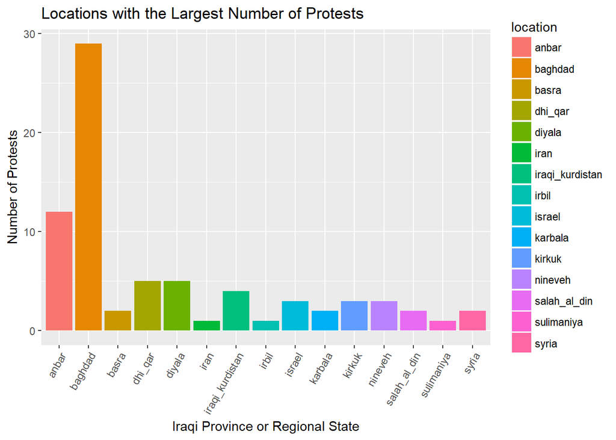

The following chart looks at Iraqi protests more carefully by examining protests with over 195 estimated participants. That Anbar and Baghdad top the list is expected considering the prior graph. Largely populated protests, however, in Iraqi-Kurdistan and, particularly, Israel, illustrate the importance of regional dynamics affecting protests in any one state. The large-scale protests in Iraqi-Kurdistan and Israel were directly related to each other as Israelis and Kurds frequently displayed each others’ flags (more on that in the following graph). The fact that protests in a foreign country, Israel, were equal to or greater in size than protests in most provinces of Iraq reveal the significance of the Kurdish independence movement to the entire Middle East region.

| location | number_of_banners | flags | population | source |
| --- | --- | --- | --- | --- |
| anbar | 7 | iraqi | 200 | international |
| anbar | 0 | iraqi_isis | 450 | regional |
| baghdad | 9 | iraqi | 200 | international |
| baghdad | 12 | iraqi | 200 | international |
| anbar | 5 | iraqi | 550 | regional |
| anbar | 8 | iraqi_syrian | 350 | international |
| anbar | 5 | iraqi_isis | 350 | international |
| baghdad | 1 | iraqi | 200 | international |
| baghdad | 5 | iraqi | 400 | international |
| baghdad | 5 | iraqi | 400 | regional |

[output cut: 9 more lines]

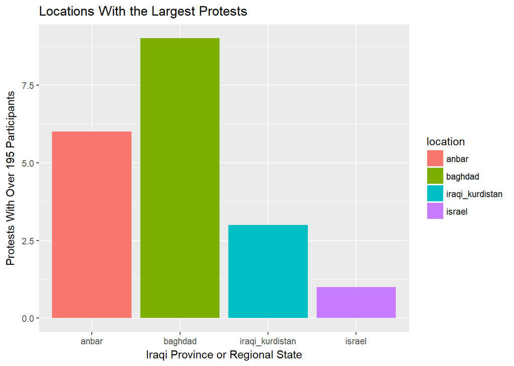

| location | number_of_banners | flags | population | source |
| --- | --- | --- | --- | --- |
| anbar | 0 | iraqi_isis | 450 | regional |
| kirkuk | 2 | none | 75 | regional |
| baghdad | 2 | iranian | 45 | international |
| salah_al_din | 3 | none | 45 | regional |
| syria | 5 | syrian | 45 | international |
| anbar | 3 | syrian | 100 | international |
| anbar | 8 | iraqi_syrian | 350 | international |
| anbar | 5 | iraqi_isis | 350 | international |
| nineveh | 0 | isis | 50 | international |
| baghdad | 8 | none | 45 | regional |

[output cut: 18 more lines]

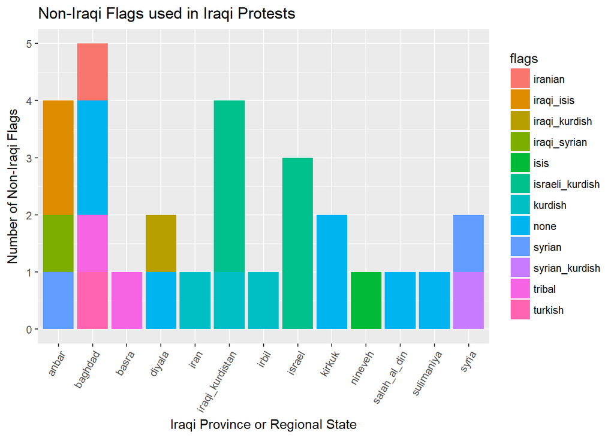

## Conclusion

The data from this project illustrates two significant points: The first is the importance of viewing Iraqi affairs through a regional lense. Political developments cannot be siloed into neat categories contained within individual states. Political, economic, social, and security issues blend together and affect citizens across national boundaries in complex and interconnected ways. The second point is the limitations of sectarianism as an explanation of Iraq’s current misfortunes. Sectarianism is certainly a major issue in Iraq, however, sectarianism is often the result of civic-based issues such as government corruption and lack of basic-services. These fundamental issues are then frequently manipulated by elites to advance sectarian agendas.

## References

http://archive.aawsat.com/details.asp?section=45&article=717909&issueno=12503#.Wg4ij2hSxPY http://www.all4syria.info/Archive/216276 // https://www.google.com/search?q=%D8%A7%D9%84%D9%85%D8%B8%D8%A7%D9%87%D8%B1%D8%A7%D8%AA+%D8%A7%D9%84%D8%B3%D9%86%D9%8A%D8%A9+%D9%81%D9%8A+%D8%A7%D9%84%D8%B9%D8%B1%D8%A7%D9%82&tbs=cdr:1,cd_min:9/1/2011,cd_max:12/31/2014&tbm=isch&source=lnms&sa=X&ved=0ahUKEwickfr5-sPXAhUB1SYKHbNDDZsQ_AUIDCgD&biw=1536&bih=734&dpr=1.25#imgrc=KBJl2GwnNocWaM: http://arb.majalla.com/2013/02/article55242222/%D8%B4%D8%A8%D8%AD-%D8%A7%D9%84%D8%AA%D9%82%D8%B3%D9%8A%D9%85-%D9%8A%D8%AE%D9%8A%D9%91%D9%85-%D8%B9%D9%84%D9%89-%D8%A7%D9%84%D8%B9%D8%B1%D8%A7%D9%82-%D9%85%D8%B1%D8%A9-%D8%A3%D8%AE%D8%B1%D9%89 http://images.alarabiya.net/0e/ee/640x392_92915_258613.jpg https://www.youtube.com/watch?v=ICwKwNPr5CQ http://www.alsumaria.tv/news/74927/ http://www.alsharq.net.sa/2013/01/26/691343 https://www.alarabiya.net/articles/2012/12/29/257690.html http://www.niqash.org/en/articles/politics/5245/ https://arabic.cnn.com/middleeast/2016/03/06/syria-demo-new-gallery https://www.npr.org/sections/thetwo-way/2015/03/11/392296775/iraqi-forces-reportedly-enter-tikrit-in-push-against-isis http://www.dw.com/ar/%D8%A7%D9%84%D9%85%D8%A7%D9%84%D9%83%D9%8A-%D8%AE%D9%8A%D8%A7%D8%B1%D8%A7%D8%AA-%D8%A7%D9%84%D8%B9%D8%B1%D8%A7%D9%82-%D8%AD%D8%B1%D8%A8-%D8%A3%D9%87%D9%84%D9%8A%D8%A9-%D8%A3%D9%88-%D8%AA%D9%82%D8%B3%D9%8A%D9%85-%D8%A3%D9%88-%D8%A7%D9%86%D8%AA%D8%AE%D8%A7%D8%A8%D8%A7%D8%AA/a-16499454 http://www.bbc.com/arabic/middleeast/2016/10/161018_mosul_city_history https://www.radiosawa.com/a/mosul-iraq-protester-killed-/219733.html http://www.aljazeera.net/news/reportsandinterviews/2014/8/22/%D8%AA%D8%B5%D8%A7%D8%B9%D8%AF-%D8%A7%D9%84%D9%85%D8%B7%D8%A7%D9%84%D8%A8-%D8%A8%D8%A5%D9%82%D8%A7%D9%85%D8%A9-%D8%A3%D9%82%D8%A7%D9%84%D9%8A%D9%85-%D8%B3%D9%86%D9%8A%D8%A9-%D8%A8%D8%A7%D9%84%D8%B9%D8%B1%D8%A7%D9%82 http://www.alsumaria.tv/news/95262/%D8%A7%D9%86%D8%B7%D9%84%D8%A7%D9%82-%D8%AA%D8%B8%D8%A7%D9%87%D8%B1%D8%A9-%D9%8A%D9%88%D9%85-%D8%A7%D9%84%D9%85%D8%B8%D9%84%D9%88%D9%85-%D9%81%D9%8A-%D8%A7%D9%84%D9%86%D8%A7%D8%B5%D8%B1%D9%8A%D8%A9-%D9%88%D8%B3/ar http://www.alsumaria.tv/news/107861/%D8%A7%D9%84%D9%85%D8%A6%D8%A7%D8%AA-%D9%8A%D8%AA%D8%B8%D8%A7%D9%87%D8%B1%D9%88%D9%86-%D9%88%D8%B3%D8%B7-%D8%A8%D8%BA%D8%AF%D8%A7%D8%AF-%D9%84%D9%84%D9%85%D8%B7%D8%A7%D9%84%D8%A8%D8%A9-%D8%A8%D8%AA%D9%88%D9%84%D9%8A/ar http://www.alhikmeh.org/news/archives/68414 http://www.almirbad.com/news/view.aspx?cdate=04112014&id=de7702af-13a0-45d1-b45b-edcc78d57085 http://www.almirbad.com/news/view.aspx?cdate=20102014&id=d089663c-86b4-431f-958e-710de5d48710 http://almadapress.com/Ar/news/22287/%D8%A7%D9%84%D8%B5%D8%AF%D8%B1-%D9%8A%D8%B1%D8%AF-%D8%B9%D9%84%D9%89-%D8%A7%D8%B3%D8%AA%D9%87%D8%AF%D8%A7%D9%81-%D8%B4%D9%8A%D9%88%D8%AE-%D8%A7%D9%84%D8%B9%D8%B4%D8%A7%D8%A6%D8%B1- http://www.aljazeera.net/news/reportsandinterviews/2016/2/28/%D9%87%D9%84-%D9%8A%D8%B1%D8%B6%D8%AE-%D8%A7%D9%84%D8%B9%D8%A8%D8%A7%D8%AF%D9%8A-%D9%84%D8%AA%D9%87%D8%AF%D9%8A%D8%AF%D8%A7%D8%AA-%D8%A7%D9%84%D8%B5%D8%AF%D8%B1 http://www.aljazeera.net/news/reportsandinterviews/2017/3/29/%D9%85%D9%82%D8%A7%D8%B7%D8%B9%D8%A9-%D8%A7%D9%84%D8%B5%D8%AF%D8%B1-%D9%84%D9%84%D8%A7%D9%86%D8%AA%D8%AE%D8%A7%D8%A8%D8%A7%D8%AA-%D9%87%D9%84-%D8%AA%D8%AE%D8%AF%D9%85-%D8%A7%D9%84%D8%AA%D8%AD%D8%A7%D9%84%D9%81-%D8%A7%D9%84%D8%B4%D9%8A%D8%B9%D9%8A http://fk-news.com/67304-%D9%85%D8%AF%D9%85%D9%86%20%D8%A7%D9%84%D9%85%D8%B8%D8%A7%D9%87%D8%B1%D8%A7%D8%AA%20%D8%A7%D9%84%D9%81%D8%A7%D8%B4%D9%84%D8%A9.html https://www.alaraby.co.uk/politics/2016/2/26/%D9%85%D9%82%D8%AA%D8%AF%D9%89-%D8%A7%D9%84%D8%B5%D8%AF%D8%B1-%D9%8A%D9%82%D9%88%D8%AF-%D9%85%D8%B8%D8%A7%D9%87%D8%B1%D8%A9-%D9%81%D9%8A-%D8%A8%D8%BA%D8%AF%D8%A7%D8%AF-%D8%B6%D8%AF-%D8%A7%D9%84%D9%81%D8%B3%D8%A7%D8%AF http://www.nasiriyah.org/ara/post/64203 http://iraq.shafaqna.com/AR/30431 http://fk-news.com/52827-%D8%AA%D8%A3%D9%8A%D9%8A%D8%AF%D8%A7%D9%8B%20%D9%84%D9%85%D8%B4%D8%B1%D9%88%D8%B9%20%D8%A7%D9%84%D8%B5%D8%AF%D8%B1%20%D8%A7%D9%84%D8%A5%D8%B5%D9%84%D8%A7%D8%AD%D9%8A%20%D8%A7%D8%AA%D8%A8%D8%A7%D8%B9%D9%87%20%D9%8A%D8%AA%D8%B8%D8%A7%D9%87%D8%B1%D9%88%D9%86%20%D9%81%D9%8A%20%D9%83%D8%B1%D8%A8%D9%84%D8%A7%D8%A1.html http://news.rthk.hk/rthk/en/component/k2/1232745-20151231.htm http://www.youm7.com/story/2017/9/18/%D8%A8%D8%A7%D9%84%D8%B5%D9%88%D8%B1-%D9%81%D9%89-%D8%A7%D9%84%D8%A7%D9%86%D9%81%D8%B5%D8%A7%D9%84-%D8%A7%D9%84%D9%83%D8%B1%D8%AF%D9%89-%D9%81%D8%AA%D8%B4-%D8%B9%D9%86-%D8%A5%D8%B3%D8%B1%D8%A7%D8%A6%D9%8A%D9%84-%D8%A7%D9%84%D9%85%D9%88%D8%B3%D8%A7%D8%AF-%D8%AF%D8%B9%D9%85-%D8%AD%D8%B1%D8%A8%D9%87%D9%85/3416436 https://www.youtube.com/watch?v=U9b8U5KLSqs http://www.elganob.com/world/56281/%D8%A8%D8%A7%D9%84%D9%81%D9%8A%D8%AF%D9%8A%D9%88-%D9%85%D8%B8%D8%A7%D9%87%D8%B1%D8%A7%D8%AA-%D9%81%D9%8A-%D8%A7%D9%8A%D8%B1%D8%A7%D9%86-%D8%A7%D8%A8%D8%AA%D9%87%D8%A7%D8%AC%D8%A7-%D8%A8%D8%A7%D9%84%D8%A5%D8%B3%D8%AA%D9%81%D8%AA%D8%A7%D8%A1-%D8%A7%D9%84%D9%83%D8%B1%D8%AF%D9%8A.html https://www.eremnews.com/news/arab-world/990274 http://www.al-masdar.net/%D8%A7%D9%84%D8%A3%D9%83%D8%B1%D8%A7%D8%AF-%D9%8A%D8%A8%D8%AD%D8%AB%D9%88%D9%86-%D8%B9%D9%86-%D8%A7%D9%84%D8%B7%D8%B1%D9%8A%D9%82-%D8%A5%D9%84%D9%89-%D9%82%D9%84%D8%A8-%D8%A5%D8%B3%D8%B1%D8%A7%D8%A6/ https://aawsat.com/home/article/1070991/%D9%85%D8%B8%D8%A7%D9%87%D8%B1%D8%A7%D8%AA-%D9%81%D9%8A-%D8%A7%D9%84%D8%B3%D9%84%D9%8A%D9%85%D8%A7%D9%86%D9%8A%D8%A9-%D8%AA%D8%B7%D8%A7%D9%84%D8%A8-%D8%A8%D8%AA%D8%BA%D9%8A%D9%8A%D8%B1-%D8%AD%D9%83%D9%88%D9%85%D8%A9-%D8%A7%D9%84%D8%A5%D9%82%D9%84%D9%8A%D9%85 http://www.alsumaria.tv/mobile/news/83715/iraq-news https://arabic.rt.com/middle_east/907547-%D8%A7%D9%84%D8%A8%D8%B1%D9%84%D9%85%D8%A7%D9%86-%D8%A7%D9%84%D8%B9%D8%B1%D8%A7%D9%82%D9%8A-%D9%8A%D8%AC%D8%B1%D9%85-%D8%B9%D9%84%D9%85-%D8%A5%D8%B3%D8%B1%D8%A7%D8%A6%D9%8A%D9%84/ https://www.i24news.tv/ar/%D8%A3%D8%AE%D8%A8%D8%A7%D8%B1/middle-east/156404-170926-%D8%A7%D8%B1%D8%AF%D9%88%D8%BA%D8%A7%D9%86-%D9%8A%D9%87%D8%AF%D8%AF-%D8%A8%D8%AA%D8%AC%D9%85%D9%8A%D8%AF-%D8%A7%D9%84%D8%B9%D9%84%D8%A7%D9%82%D8%A7%D8%AA-%D9%85%D8%B9-%D8%A5%D8%B3%D8%B1%D8%A7%D8%A6%D9%8A%D9%84-%D8%A7%D8%B0%D8%A7-%D9%88%D8%A7%D8%B5%D9%84%D8%AA-%D8%A8%D8%AF%D8%B9%D9%85-%D8%A7%D8%B3%D8%AA%D9%82%D9%84%D8%A7%D9%84-%D9%83%D8%B1%D8%AF%D8%B3%D8%AA%D8%A7%D9%86 https://twitter.com/freelaancenews/status/911509193647157248 http://www.aljazeera.net/news/presstour/2017/9/27/%D9%86%D9%8A%D9%88%D9%8A%D9%88%D8%B1%D9%83-%D8%AA%D8%A7%D9%8A%D9%85%D8%B2-%D8%A7%D8%B3%D8%AA%D9%81%D8%AA%D8%A7%D8%A1-%D9%83%D8%B1%D8%AF%D8%B3%D8%AA%D8%A7%D9%86-%D8%AE%D8%B7%D9%8A%D8%B1-%D9%88%D8%BA%D9%8A%D8%B1-%D8%AD%D9%83%D9%8A%D9%85 https://www.nytimes.com/2015/09/01/world/middleeast/protests-in-iraq-bring-fast-promises-but-slower-changes.html?mtrref=www.google.com https://euphrates.org/iraq-institutes-sweeping-reforms-amidst-popular-protests/ https://www.timesofisrael.com/braving-heat-throngs-protest-government-corruption-in-baghdad/ http://stream.aljazeera.com/story/201508181816-0024957 http://worldinstruggle.blogspot.com/2013/03/iraq-mass-marches-against-sectarian-govt.html http://www.iraqicivilsociety.org/archives/1614 http://www.nytimes.com/2008/11/22/world/middleeast/22iraq.html?mtrref=www.google.com&gwh=6A0B433F209FF667E809851606C9F2F5&gwt=pay https://www.voanews.com/a/kurdistan-region-iraq-international-flights-canceled-protests/4049942.html http://www.harmees.com/articles/view/93280.html http://harmees.com/articles/view/70398?fb_comment_id=487794297898209_6044252#f6f0b6c87479f8 http://badrnews.net/home/single_news/74061 https://www.baghdad-times.net/2015/08/07/%D8%B9%D8%B1%D8%A7%D9%82%D9%8A%D9%88%D9%86-%D9%8A%D8%AA%D8%B8%D8%A7%D9%87%D8%B1%D9%88%D9%86-%D9%81%D9%8A-%D8%A8%D9%8A%D8%B1%D9%88%D8%AA-%D9%88%D8%B9%D9%85%D9%91%D8%A7%D9%86-%D8%AA%D8%B6%D8%A7%D9%85/ http://www.themalaymailonline.com/world/article/iraqis-take-to-the-street-in-angry-protests-over-poor-services#ryc5eMpH9gSH9duF.97 http://www.alquds.co.uk/?p=384017 http://www.aljazeera.net/news/reportsandinterviews/2013/1/6/%D9%85%D8%B4%D8%A7%D8%B1%D9%83%D8%A9-%D9%86%D8%B3%D8%A7%D8%A6%D9%8A%D8%A9-%D9%81%D9%8A-%D9%85%D8%B8%D8%A7%D9%87%D8%B1%D8%A9-%D8%A7%D9%84%D8%A3%D9%86%D8%A8%D8%A7%D8%B1 http://www.iraaqi.com/news.php?id=2978&news=1#.Wop1E6inFPY http://www.dhiqar.net/Rep.php?rep=5003 http://www.thebaghdadpost.com/ar/story/30175/%D8%A7%D9%86%D8%B7%D9%84%D8%A7%D9%82-%D8%AA%D8%B8%D8%A7%D9%87%D8%B1%D8%A9-%D9%83%D8%A8%D8%B1%D9%89-%D9%81%D9%8A-%D8%AF%D9%8A%D8%A7%D9%84%D9%89-%D8%B6%D8%AF-%D9%82%D8%A7%D9%86%D9%88%D9%86-%D9%88%D9%85%D9%81%D9%88%D8%B6%D9%8A%D8%A9-%D8%A7%D9%84%D8%A7%D9%86%D8%AA%D8%AE%D8%A7%D8%A8%D8%A7%D8%AA